# Unmasking Alternative Funding Programs Comparator Study

# 1 Study Overview

## 1.1 Background

A growing number of self-employed companies have started using Alternative Funding Programs (AFPs) to completely exclude specialty medications (used to treat complex chronic, expensive conditions like cancer, MS, and RA) from being covered by a patient’s pharmacy benefit. These AFPs work by forcing patients to sign up for manufacturer assistance (meant for uninsured patients) or getting the medication internationally.

There is currently a complete lack of data on the frequency of these programs and their impact on patients.

## 1.2 Outcomes

The primary outcome was medication access, defined as the referred medication, or an appropriate alternative, being covered (by insurance or alternative means) so the patient could access treatment. Secondary outcomes were how the medication was accessed, time to access (defined as time from referral to the estimated date patient received medication), the occurrence of a gap in therapy, rate of manufacturer patient assistance program (PAP) application, and pharmacist time spent on the access process.

## 1.3 Inclusions and Exclusions

- All patients identified to be in an AFP in 2024 or 2025 (not required to be the first time they are identified).
- Comparator group of non-AFP patients that were randomly selected at a 2:1 ratio with the AFP patients matched by disease state and patient status. Patients with carve out plans or maximizers were excluded from the selection process.

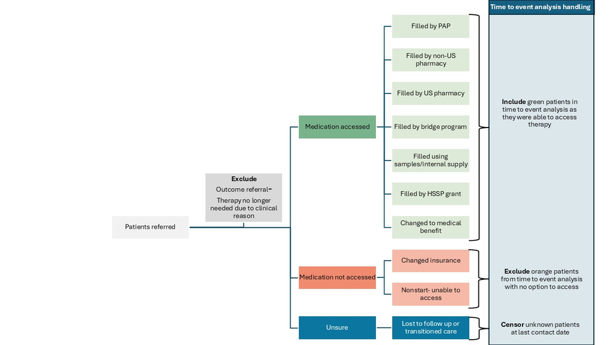

# 2 Descriptive Statistics

## 2.1 Demographics

| **Characteristic** | **N** | **AFP Status** **AFP** N = 299<sup>1</sup> | **AFP Status** **Non-AFP** N = 547<sup>1</sup> |
| --- | --- | --- | --- |
| Year | 846 |  |  |
| 2024 |  | 227 (75.9%) | 473 (86.5%) |
| 2025 |  | 72 (24.1%) | 74 (13.5%) |
| Age | 816 |  |  |
| Mean (SD) |  | 45.6 (14.8) | 51.1 (17.3) |
| Median (Q1 - Q3) |  | 47.0 (35.0 - 57.0) | 53.0 (39.0 - 63.0) |
| Min - Max |  | 2.0 - 83.0 | 4.0 - 93.0 |
| Missing |  | 11 | 19 |
| Sex | 846 |  |  |
| Male |  | 109 (36.5%) | 252 (46.1%) |
| Female |  | 189 (63.2%) | 293 (53.6%) |
| Other |  | 1 (0.33%) | 2 (0.37%) |
| Ethnicity | 828 |  |  |
| Not Hispanic, Latino/a, or Spanish origin |  | 257 (91.5%) | 484 (88.5%) |
| Hispanic or Latino |  | 5 (1.78%) | 14 (2.56%) |
| Unknown |  | 1 (0.36%) | 16 (2.93%) |
| Decline to Answer |  | 4 (1.42%) | 15 (2.74%) |
| Mexican, Mexican American, or Chicano/a |  | 1 (0.36%) | 0 (0%) |
| Puerto Rican |  | 1 (0.36%) | 1 (0.18%) |
| Cuban |  | 0 (0%) | 1 (0.18%) |
| Other Hispanic, Latino/a, or Spanish origin |  | 2 (0.71%) | 4 (0.73%) |
| Not available |  | 10 (3.56%) | 12 (2.19%) |
| Missing |  | 18 | 0 |
| Race | 846 |  |  |
| Black or African American |  | 21 (7.02%) | 65 (11.9%) |
| Other |  | 10 (3.34%) | 24 (4.39%) |
| Unknown |  | 10 (3.34%) | 11 (2.01%) |
| White |  | 258 (86.3%) | 447 (81.7%) |
| Clinic | 846 |  |  |
| Cardiology |  | 6 (2.01%) | 12 (2.19%) |
| Dermatology |  | 30 (10.0%) | 56 (10.2%) |
| Endocrinology |  | 5 (1.67%) | 10 (1.83%) |
| GI/IBD |  | 59 (19.7%) | 102 (18.6%) |
| Hepatology (non-hepatitis) |  | 2 (0.67%) | 4 (0.73%) |
| HIV |  | 6 (2.01%) | 12 (2.19%) |
| HCV |  | 2 (0.67%) | 3 (0.55%) |
| Other Infectious Diseases |  | 1 (0.33%) | 2 (0.37%) |
| Oncology/hematology |  | 55 (18.4%) | 98 (17.9%) |
| Non-MS Neurology |  | 9 (3.01%) | 15 (2.74%) |
| MS |  | 30 (10.0%) | 54 (9.87%) |
| Pediatric Inflammatory |  | 2 (0.67%) | 4 (0.73%) |
| Pediatric, Other |  | 1 (0.33%) | 2 (0.37%) |
| Pulmonology |  | 9 (3.01%) | 18 (3.29%) |
| Rheumatology |  | 67 (22.4%) | 133 (24.3%) |
| Transplant |  | 1 (0.33%) | 2 (0.37%) |
| Other |  | 14 (4.68%) | 20 (3.66%) |
| Referral Status | 846 |  |  |
| Continuing therapy |  | 171 (57.2%) | 312 (57.0%) |
| New medication |  | 128 (42.8%) | 235 (43.0%) |

<sup>1</sup> n (%)

## 2.2 Outcomes

| **Characteristic** | **N** | **AFP Status** **AFP** N = 299<sup>1</sup> | **AFP Status** **Non-AFP** N = 547<sup>1</sup> |
| --- | --- | --- | --- |
| Medication Accessed | 846 |  |  |
| No |  | 24 (8.03%) | 5 (0.91%) |
| Unknown |  | 19 (6.35%) | 9 (1.65%) |
| Yes |  | 256 (85.6%) | 533 (97.4%) |
| Referral Outcome | 846 |  |  |
| Filled through manufacturer PAP |  | 84 (28.1%) | 23 (4.20%) |
| Filled by a non-US pharmacy |  | 56 (18.7%) | 0 (0%) |
| Filled by a US pharmacy (original product or alternative) |  | 102 (34.1%) | 493 (90.1%) |
| Patient lost to follow up during access process |  | 19 (6.35%) | 8 (1.46%) |
| Medication changed to medical benefit medication |  | 8 (2.68%) | 11 (2.01%) |
| Patient changed insurance to get medication approved |  | 12 (4.01%) | 0 (0%) |
| Filled through Manufacturer Bridge Program |  | 2 (0.67%) | 1 (0.18%) |
| Nonstart- never accessed treatment |  | 12 (4.01%) | 5 (0.91%) |
| Filled using samples or internal supply |  | 2 (0.67%) | 5 (0.91%) |
| Filled at HSSP covered by internal grant |  | 2 (0.67%) | 0 (0%) |
| Transitioned care during access process |  | 0 (0%) | 1 (0.18%) |
| Time to Access | 789 |  |  |
| Mean (SD) |  | 42.7 (36.0) | 14.6 (18.7) |
| Median (Q1 - Q3) |  | 33.0 (19.0 - 55.0) | 9.0 (5.0 - 17.0) |
| Min - Max |  | 0.0 - 235.0 | 0.0 - 225.0 |
| Missing |  | 43 | 14 |

<sup>1</sup> n (%)

## 2.3 PAP and appeals

| **Characteristic** | **N** | **AFP Status** **AFP** N = 299<sup>1</sup> | **AFP Status** **Non-AFP** N = 547<sup>1</sup> |
| --- | --- | --- | --- |
| Applied for PAP | 845 |  |  |
| No |  | 104 (34.8%) | 499 (91.4%) |
| Yes |  | 195 (65.2%) | 47 (8.61%) |
| Missing |  | 0 | 1 |
| PAP approved | 242 |  |  |
| No |  | 107 (54.9%) | 6 (12.8%) |
| Yes |  | 88 (45.1%) | 41 (87.2%) |
| Missing |  | 104 | 500 |
| PAP denial reason | 113 |  |  |
| Overqualified financially |  | 9 (8.41%) | 4 (66.7%) |
| Identified AFP enrollment |  | 53 (49.5%) | 0 (0%) |
| Incomplete PAP enrollment paperwork |  | 4 (3.74%) | 2 (33.3%) |
| Unknown |  | 24 (22.4%) | 0 (0%) |
| Other |  | 17 (15.9%) | 0 (0%) |
| Missing |  | 192 | 541 |
| Samples | 846 |  |  |
| Yes |  | 34 (11.4%) | 11 (2.01%) |
| No |  | 258 (86.3%) | 534 (97.6%) |
| Unsure |  | 7 (2.34%) | 2 (0.37%) |
| Override fill provided | 299 |  |  |
| No |  | 258 (86.3%) | 0 (NA%) |
| Yes |  | 41 (13.7%) | 0 (NA%) |
| Missing |  | 0 | 547 |
| PA submitted | 846 |  |  |
| No |  | 85 (28.4%) | 207 (37.8%) |
| Yes |  | 214 (71.6%) | 340 (62.2%) |
| Appeal submitted | 846 |  |  |
| No |  | 278 (93.0%) | 525 (96.0%) |
| Yes |  | 21 (7.02%) | 22 (4.02%) |

<sup>1</sup> n (%)

## 2.4 Gaps

Only for patients continuing therapy

| **Characteristic** | **N** | **AFP Status** **AFP** N = 171<sup>1</sup> | **AFP Status** **Non-AFP** N = 312<sup>1</sup> |
| --- | --- | --- | --- |
| Treatment gap | 483 |  |  |
| Yes |  | 49 (28.7%) | 6 (1.92%) |
| No |  | 104 (60.8%) | 295 (94.6%) |
| Unknown |  | 18 (10.5%) | 11 (3.53%) |
| Number of days not covered | 55 |  |  |
| 0-30 days |  | 20 (40.8%) | 4 (66.7%) |
| 31-90 days |  | 12 (24.5%) | 2 (33.3%) |
| >90 days |  | 6 (12.2%) | 0 (0%) |
| Unknown |  | 11 (22.4%) | 0 (0%) |
| Missing |  | 122 | 306 |

<sup>1</sup> n (%)

## 2.5 PharmD time

| **Characteristic** | **N** | **AFP Status** **AFP** N = 299 | **AFP Status** **Non-AFP** N = 547 |
| --- | --- | --- | --- |
| PharmD time spent on access | 846 |  |  |
| Mean (SD) |  | 3.4 (3.5) | 1.2 (1.1) |
| Median (Q1 - Q3) |  | 2.0 (1.0 - 4.0) | 1.0 (0.5 - 2.0) |
| Min - Max |  | 0.5 - 30.0 | 0.0 - 10.0 |

## 2.6 Poor clinical outcome

| **Characteristic** | **N** | **AFP Status** **AFP** N = 299<sup>1</sup> | **AFP Status** **Non-AFP** N = 547<sup>1</sup> |
| --- | --- | --- | --- |
| Any poor clinical outcomes | 846 |  |  |
| No poor clinical outcome |  | 272 (91.0%) | 540 (98.7%) |
| Poor clinical outcome |  | 27 (9.03%) | 7 (1.28%) |
| Number of poor clinical outcomes | 846 |  |  |
| 0 |  | 272 (91.0%) | 540 (98.7%) |
| 1 |  | 27 (9.03%) | 7 (1.28%) |
| Disease progression/worsening/flare | 846 | 23 (7.69%) | 6 (1.10%) |
| Disease-related non-scheduled clinic visit | 846 | 3 (1.00%) | 0 (0%) |
| Disease-related urgent care/ED visit | 846 | 1 (0.33%) | 0 (0%) |
| Disease-related hospitalization | 846 | 0 (0%) | 1 (0.18%) |
| None of the above | 846 | 168 (56.2%) | 525 (96.0%) |
| Unsure | 846 | 102 (34.1%) | 14 (2.56%) |

<sup>1</sup> n (%)

## 2.7 Human Resources Communication

| **Characteristic** | **N** | **AFP Status** **AFP** N = 299<sup>1</sup> | **AFP Status** **Non-AFP** N = 547<sup>1</sup> |
| --- | --- | --- | --- |
| Communicated with HR department during access process | 298 |  |  |
| Yes |  | 18 (6.04%) | 0 (NA%) |
| No |  | 110 (36.9%) | 0 (NA%) |
| Unknown |  | 170 (57.0%) | 0 (NA%) |
| Appeal to override AFP process | 846 | 8 (2.68%) | 0 (0%) |
| Voiced concern about the AFP process | 846 | 5 (1.67%) | 0 (0%) |
| Discussed explanation of benefits/AFP process | 846 | 5 (1.67%) | 0 (0%) |
| Other | 846 | 1 (0.33%) | 0 (0%) |
| Unknown | 846 | 3 (1.00%) | 0 (0%) |

<sup>1</sup> n (%)

## 2.8 Method of AFP Identification by HSSP

| **Characteristic** | **N** | **N = 299**<sup>1</sup> |
| --- | --- | --- |
| Method of AFP identification | 299 |  |
| Access approved, but forced to sign up for AFP |  | 68 (22.7%) |
| Access approved, patient must apply for PAP |  | 5 (1.67%) |
| Access denied, patient must apply for PAP |  | 15 (5.02%) |
| Access denied, patient must contact AFP |  | 53 (17.7%) |
| AFP contacted clinic for therapy change |  | 5 (1.67%) |
| AFP contacted clinic to apply for PAP |  | 14 (4.68%) |
| AFP contacted patient directly |  | 9 (3.01%) |
| Identified by PAP |  | 26 (8.70%) |
| No option to submit PA or appeal, directed to PAP |  | 45 (15.1%) |
| On BI, ineligible for HSSP, contact AFP |  | 31 (10.4%) |
| Prescription required to be sent internationally |  | 21 (7.02%) |
| Other |  | 5 (1.67%) |
| Unknown |  | 2 (0.67%) |

<sup>1</sup> n (%)

# 3 Analysis

**Note**

Patients with an outcome referral of “Therapy no longer needed” are removed from every section below

## 3.1 Outcome Descriptive Statistics

### 3.1.1 Table

| **Characteristic** | **N** | **afp** **Non-AFP** N = 547<sup>1</sup> | **afp** **AFP** N = 299<sup>1</sup> |
| --- | --- | --- | --- |
| Medication Accessed | 846 |  |  |
| No |  | 5 (0.91%) | 24 (8.03%) |
| Unknown |  | 9 (1.65%) | 19 (6.35%) |
| Yes |  | 533 (97.4%) | 256 (85.6%) |
| Time to Access | 789 |  |  |
| Mean (SD) |  | 14.6 (18.7) | 42.7 (36.0) |
| Median (Q1 - Q3) |  | 9.0 (5.0 - 17.0) | 33.0 (19.0 - 55.0) |
| Min - Max |  | 0.0 - 225.0 | 0.0 - 235.0 |
| Missing |  | 14 | 43 |
| Any poor clinical outcomes | 846 |  |  |
| No poor clinical outcome |  | 540 (98.7%) | 272 (91.0%) |
| Poor clinical outcome |  | 7 (1.28%) | 27 (9.03%) |
| Referral Outcome | 846 |  |  |
| Filled through manufacturer PAP |  | 23 (4.20%) | 84 (28.1%) |
| Filled by a non-US pharmacy |  | 0 (0%) | 56 (18.7%) |
| Filled by a US pharmacy (original product or alternative) |  | 493 (90.1%) | 102 (34.1%) |
| Patient lost to follow up during access process |  | 8 (1.46%) | 19 (6.35%) |
| Medication changed to medical benefit medication |  | 11 (2.01%) | 8 (2.68%) |
| Patient changed insurance to get medication approved |  | 0 (0%) | 12 (4.01%) |
| Filled through Manufacturer Bridge Program |  | 1 (0.18%) | 2 (0.67%) |
| Nonstart- never accessed treatment |  | 5 (0.91%) | 12 (4.01%) |
| Filled using samples or internal supply |  | 5 (0.91%) | 2 (0.67%) |
| Filled at HSSP covered by internal grant |  | 0 (0%) | 2 (0.67%) |
| Transitioned care during access process |  | 1 (0.18%) | 0 (0%) |

<sup>1</sup> n (%)

### 3.1.2 Figures

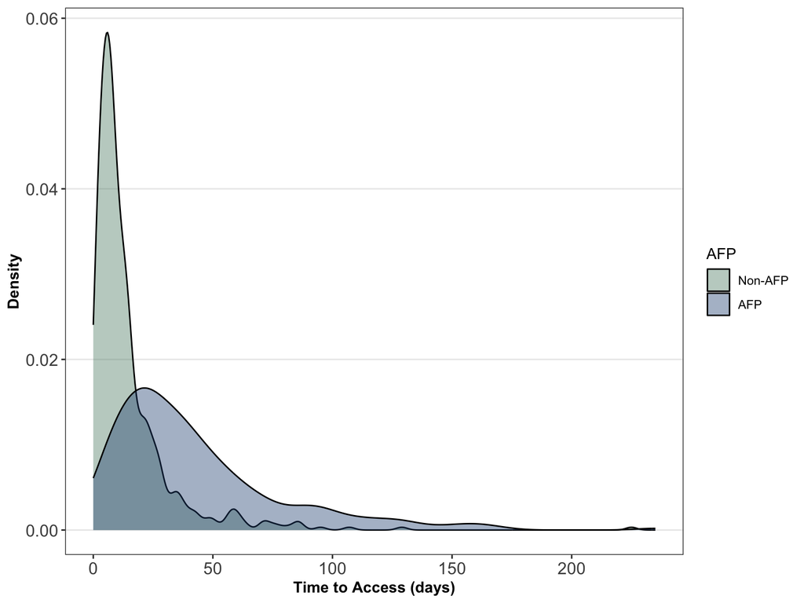

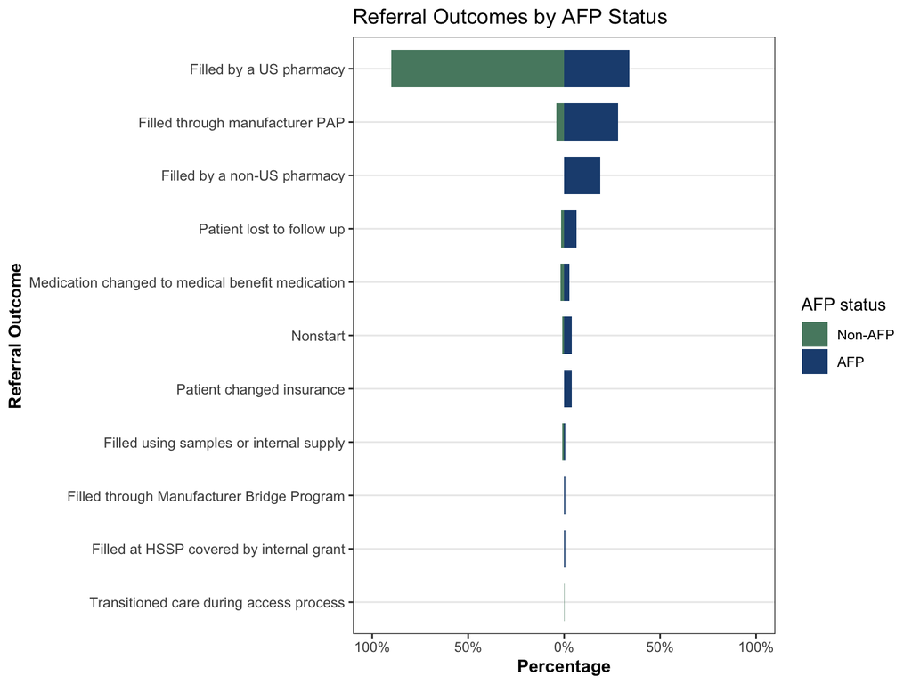

## 3.2 Primary Outcome - Medication Access

### 3.2.1 Descriptives by status and afp

| **Group** | **Non-AFP / Continuing therapy** N = 312<sup>1</sup> | **AFP / Continuing therapy** N = 171<sup>1</sup> | **Non-AFP / New medication** N = 235<sup>1</sup> | **AFP / New medication** N = 128<sup>1</sup> |
| --- | --- | --- | --- | --- |
| med_access |  |  |  |  |
| No | 0 (0.0%) | 11 (6.4%) | 5 (2.1%) | 13 (10.2%) |
| Unknown | 2 (0.6%) | 6 (3.5%) | 7 (3.0%) | 13 (10.2%) |
| Yes | 310 (99.4%) | 154 (90.1%) | 223 (94.9%) | 102 (79.7%) |

<sup>1</sup> n (%)

### 3.2.2 Mixed effects logistic regression model

**Unadjusted**

Medication access has 28 values of “unknown” for certain patients, but a logistic mixed model requires a strictly two-level outcome. To proceed, several approaches were taken.

**Drop Unsure and Unknown**

Mixed-Effects Logistic Regression Results: Medication Access (Unknown is dropped)

| Term | Log(OR) | Odds Ratio | 95% CI for OR Lower | 95% CI for OR Upper | P-value |
| --- | --- | --- | --- | --- | --- |
| (Intercept) | 4.68 | 107.52 | 43.32 | 266.87 | <0.001 |
| afpAFP | -2.31 | 0.10 | 0.04 | 0.26 | <0.001 |

###### 3.2.2.0.0.1 Predicted probabilities and risk ratio

Predicted probabilities

|  | Predicted Probability | 95% CI Lower Bound | 95% CI Upper Bound |
| --- | --- | --- | --- |
| Non-AFP | 0.9908626 | 0.9826317 | 0.9990936 |
| AFP | 0.9151272 | 0.8778527 | 0.9524017 |

Risk ratio

|  | Risk Ratio | 95% CI Lower Bound | 95% CI Upper Bound |
| --- | --- | --- | --- |
| AFP / Non-AFP | 0.9235662 | 0.8861072 | 0.9610252 |

**Count Unknown and Unsure as No Access**

Mixed-Effects Logistic Regression Results: Medication Access (Unknown is No)

| Term | Log(OR) | Odds Ratio | 95% CI for OR Lower | 95% CI for OR Upper | P-value |
| --- | --- | --- | --- | --- | --- |
| (Intercept) | 3.65 | 38.39 | 19.81 | 74.41 | <0.001 |
| afpAFP | -1.91 | 0.15 | 0.08 | 0.28 | <0.001 |

###### 3.2.2.0.0.2 Predicted probabilities and risk ratio

Predicted probabilities

|  | Predicted Probability | 95% CI Lower Bound | 95% CI Upper Bound |
| --- | --- | --- | --- |
| Non-AFP | 0.9819209 | 0.9701729 | 0.9936689 |
| AFP | 0.8892030 | 0.8384155 | 0.9399905 |

Risk ratio

|  | Risk Ratio | 95% CI Lower Bound | 95% CI Upper Bound |
| --- | --- | --- | --- |
| AFP / Non-AFP | 0.9055749 | 0.8578751 | 0.9532748 |

**Count Unknown and Unsure as Access**

Mixed-Effects Logistic Regression Results: Medication Access (Unknown is Yes)

| Term | Log(OR) | Odds Ratio | 95% CI for OR Lower | 95% CI for OR Upper | P-value |
| --- | --- | --- | --- | --- | --- |
| (Intercept) | 4.69 | 109.37 | 44.22 | 270.50 | <0.001 |
| afpAFP | -2.25 | 0.11 | 0.04 | 0.28 | <0.001 |

###### 3.2.2.0.0.3 Predicted probabilities and risk ratio

Predicted probabilities

|  | Predicted Probability | 95% CI Lower Bound | 95% CI Upper Bound |
| --- | --- | --- | --- |
| Non-AFP | 0.9908923 | 0.9827199 | 0.9990646 |
| AFP | 0.9198320 | 0.8853187 | 0.9543452 |

Risk ratio

|  | Risk Ratio | 95% CI Lower Bound | 95% CI Upper Bound |
| --- | --- | --- | --- |
| AFP / Non-AFP | 0.9282866 | 0.893432 | 0.9631412 |

**Adjusted for referral status**

Medication access has 28 values of “unknown” for certain patients, but a logistic mixed model requires a strictly two-level outcome. To proceed, several approaches were taken.

**Drop Unsure and Unknown**

Mixed-Effects Logistic Regression Results: Medication Access (Unknown is dropped)

| Term | Log(OR) | Odds Ratio | 95% CI for OR Lower | 95% CI for OR Upper | P-value |
| --- | --- | --- | --- | --- | --- |
| (Intercept) | 5.24 | 188.16 | 62.99 | 562.12 | <0.001 |
| afpAFP | -2.34 | 0.10 | 0.04 | 0.25 | <0.001 |
| referralNew medication | -0.98 | 0.38 | 0.17 | 0.84 | 0.017 |

###### 3.2.2.0.0.4 Predicted probabilities and risk ratio

Predicted probabilities

|  |  | Predicted Probability | 95% CI Lower Bound | 95% CI Upper Bound |
| --- | --- | --- | --- | --- |
| Non-AFP | Continuing therapy | 0.9943195 | 0.9881381 | 1.0005010 |
| Non-AFP | New medication | 0.9850452 | 0.9706927 | 0.9993978 |
| AFP | Continuing therapy | 0.9438998 | 0.9040783 | 0.9837213 |
| AFP | New medication | 0.8635993 | 0.7904286 | 0.9367700 |

Risk ratio

|  |  | Risk Ratio | 95% CI Lower Bound | 95% CI Upper Bound |
| --- | --- | --- | --- | --- |
| AFP / Non-AFP | Continuing therapy | 0.9492922 | 0.9118097 | 0.9867747 |
| AFP / Non-AFP | New medication | 0.8767103 | 0.8054664 | 0.9479542 |

**Count Unknown and Unsure as No Access**

Mixed-Effects Logistic Regression Results: Medication Access (Unknown is No)

| Term | Log(OR) | Odds Ratio | 95% CI for OR Lower | 95% CI for OR Upper | P-value |
| --- | --- | --- | --- | --- | --- |
| (Intercept) | 4.21 | 67.15 | 31.76 | 141.99 | <0.001 |
| afpAFP | -1.93 | 0.14 | 0.08 | 0.27 | <0.001 |
| referralNew medication | -1.01 | 0.37 | 0.20 | 0.67 | 0.001 |

###### 3.2.2.0.0.5 Predicted probabilities and risk ratio

Predicted probabilities

|  |  | Predicted Probability | 95% CI Lower Bound | 95% CI Upper Bound |
| --- | --- | --- | --- | --- |
| Non-AFP | Continuing therapy | 0.9882299 | 0.9795205 | 0.9969392 |
| Non-AFP | New medication | 0.9684434 | 0.9482179 | 0.9886690 |
| AFP | Continuing therapy | 0.9240837 | 0.8816615 | 0.9665058 |
| AFP | New medication | 0.8164875 | 0.7373469 | 0.8956281 |

Risk ratio

|  |  | Risk Ratio | 95% CI Lower Bound | 95% CI Upper Bound |
| --- | --- | --- | --- | --- |
| AFP / Non-AFP | Continuing therapy | 0.9350898 | 0.8964055 | 0.9737741 |
| AFP / Non-AFP | New medication | 0.8430926 | 0.7678088 | 0.9183764 |

**Count Unknown and Unsure as Access**

Mixed-Effects Logistic Regression Results: Medication Access (Unknown is Yes)

| Term | Log(OR) | Odds Ratio | 95% CI for OR Lower | 95% CI for OR Upper | P-value |
| --- | --- | --- | --- | --- | --- |
| (Intercept) | 5.22 | 185.19 | 62.25 | 550.91 | <0.001 |
| afpAFP | -2.27 | 0.10 | 0.04 | 0.27 | <0.001 |
| referralNew medication | -0.92 | 0.40 | 0.18 | 0.90 | 0.026 |

###### 3.2.2.0.0.6 Predicted probabilities and risk ratio

Predicted probabilities

|  |  | Predicted Probability | 95% CI Lower Bound | 95% CI Upper Bound |
| --- | --- | --- | --- | --- |
| Non-AFP | Continuing therapy | 0.9940790 | 0.9876623 | 1.0004958 |
| Non-AFP | New medication | 0.9853126 | 0.9711798 | 0.9994455 |
| AFP | Continuing therapy | 0.9456558 | 0.9067631 | 0.9845485 |
| AFP | New medication | 0.8742639 | 0.8062781 | 0.9422498 |

Risk ratio

|  |  | Risk Ratio | 95% CI Lower Bound | 95% CI Upper Bound |
| --- | --- | --- | --- | --- |
| AFP / Non-AFP | Continuing therapy | 0.9512884 | 0.9148134 | 0.9877633 |
| AFP / Non-AFP | New medication | 0.8872960 | 0.8213227 | 0.9532693 |

### 3.2.3 Figure

This figures uses the results from counting unknown as no access.

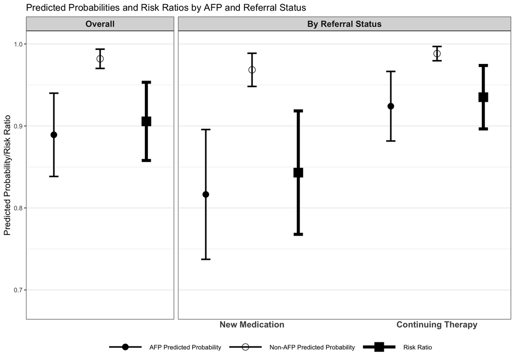

## 3.3 Secondary Outcomes

### 3.3.1 Poor clinical outcome

- Outcome events were limited: 27 cases among 299 AFP participants and 7 cases among 547 non-AFP participants.
- Mixed-effects logistic regression may be unstable due to the small number of outcome events within sites.
- A standard logistic regression model without random effects was fit as a sensitivity analysis; results were similar, indicating that sparse site-level may not affect conclusions.

#### 3.3.1.1 Descriptives by status and afp

| **Group** | **Non-AFP / Continuing therapy** N = 312<sup>1</sup> | **AFP / Continuing therapy** N = 171<sup>1</sup> | **Non-AFP / New medication** N = 235<sup>1</sup> | **AFP / New medication** N = 128<sup>1</sup> |
| --- | --- | --- | --- | --- |
| Any poor clinical outcomes |  |  |  |  |
| No poor clinical outcome | 311 (99.7%) | 158 (92.4%) | 229 (97.4%) | 114 (89.1%) |
| Poor clinical outcome | 1 (0.3%) | 13 (7.6%) | 6 (2.6%) | 14 (10.9%) |

<sup>1</sup> n (%)

**Mixed effects logistic regression model**

Mixed-Effects Logistic Regression Results: Poor clinical outcome

| Term | Log(OR) | Odds Ratio | 95% CI for OR Lower | 95% CI for OR Upper | P-value |
| --- | --- | --- | --- | --- | --- |
| (Intercept) | -4.85 | 0.01 | 0.00 | 0.02 | <0.001 |
| afpAFP | 2.11 | 8.22 | 3.55 | 19.03 | <0.001 |
| referralNew medication | 0.72 | 2.05 | 0.98 | 4.29 | 0.058 |

**Logistic Regression with Robust Sandwich Estimator sensitivity analysis**

```
Logistic Regression Model

lrm(formula = poor_clinc_any ~ afp + referral, data = moddat,
    x = TRUE, y = TRUE)

                                  Model Likelihood     Discrimination    Rank Discrim.
                                        Ratio Test            Indexes          Indexes
     Obs                 846    LR chi2      32.70     R2       0.132    C       0.772
 No poor clinical outcome812    d.f.             2     R2(2,846)0.036    Dxy     0.545
     Poor clinical outcome34    Pr(> chi2) <0.0001    R2(2,97.9)0.269    gamma   0.675
     Cluster on  moddat$site                           Brier    0.037    tau-a   0.042
     Clusters             11
     max |deriv|       1e-09

                        Coef    S.E.   Wald Z Pr(>|Z|)
Intercept               -4.7043 0.5477 -8.59  <0.0001
afp=AFP                  2.0463 0.6094  3.36  0.0008
referral=New medication  0.6978 0.3745  1.86  0.0624
```

### 3.3.2 Time to access

#### 3.3.2.1 Descriptives by status and afp

| **Group** | **Non-AFP / Continuing therapy** N = 312 | **AFP / Continuing therapy** N = 171 | **Non-AFP / New medication** N = 235 | **AFP / New medication** N = 128 |
| --- | --- | --- | --- | --- |
| Time to Access |  |  |  |  |
| Mean (SD) | 12.8 (15.3) | 44.5 (37.7) | 17.2 (22.2) | 39.9 (33.4) |
| Median (Q1 - Q3) | 8.0 (4.3 - 14.0) | 35.0 (19.0 - 61.3) | 11.0 (6.0 - 21.0) | 29.5 (20.0 - 47.5) |
| Min - Max | 0.0 - 95.0 | 0.0 - 235.0 | 0.0 - 225.0 | 3.0 - 162.0 |
| Missing | 2 | 17 | 12 | 26 |

| **Characteristic** | **N** | **outcome_referral** **Filled through manufacturer PAP** N = 29 | **outcome_referral** **Filled by a non-US pharmacy** N = 28 | **outcome_referral** **Filled by a US pharmacy (original product or alternative)** N = 222 | **outcome_referral** **Patient lost to follow up during access process** N = 4 | **outcome_referral** **Medication changed to medical benefit medication** N = 3 | **outcome_referral** **Patient changed insurance to get medication approved** N = 5 | **outcome_referral** **Filled through Manufacturer Bridge Program** N = 3 | **outcome_referral** **Therapy no longer needed/PURSUED FOR CLINICAL REASONS DURING ACCESS PROCESS** N = 0 | **Nonstart- never accessed treatment** N = 6 | **Other** N = 0 | **Filled using samples or internal supply** N = 0 | **Filled at HSSP covered by internal grant** N = 0 | **Transitioned care during access process** N = 0 |  |  |  |  |  |
| --- | --- | --- | --- | --- | --- | --- | --- | --- | --- | --- | --- | --- | --- | --- | --- | --- | --- | --- | --- |
| Time to Access | 285 |  |  |  |  |  |  |  |  |  |  |  |  |  |  |  |  |  |  |
| Mean (SD) |  | 50.9 (36.7) | 52.7 (38.6) | 18.3 (22.5) | NA (NA) | 58.0 (55.7) | NA (NA) | 21.7 (13.5) | NA (NA) | NA (NA) | NA (NA) | NA (NA) | NA (NA) | NA (NA) |  |  |  |  |  |
| Median (Q1 - Q3) |  | 43.0 (29.0 - 67.0) | 45.5 (18.5 - 86.5) | 10.5 (6.0 - 21.0) | NA (NA - NA) | 32.0 (20.0 - 122.0) | NA (NA - NA) | 22.0 (8.0 - 35.0) | NA (NA - NA) | NA (NA - NA) | NA (NA - NA) | NA (NA - NA) | NA (NA - NA) | NA (NA - NA) |  |  |  |  |  |
| Min - Max |  | 4.0 - 169.0 | 6.0 - 128.0 | 0.0 - 149.0 | Inf - -Inf | 20.0 - 122.0 | Inf - -Inf | 8.0 - 35.0 | Inf - -Inf | Inf - -Inf | Inf - -Inf | Inf - -Inf | Inf - -Inf | Inf - -Inf |  |  |  |  |  |
| Missing |  | 0 | 0 | 0 | 4 | 0 | 5 | 0 | 0 | 6 | 0 | 0 | 0 | 0 |  |  |  |  |  |

#### 3.3.2.2 Modeling

**Survival model**

- Time to access is censored if patients are lost to followup or transitioned care
- Patients for whom medication is not able to be accessed are excluded from the analysis as they are not applicable according to the table.
  - Nonstart
  - Therapy no longer needed
  - Patient changed insurance to get medication approved
- 817 patients are included in the analysis

```
          censor dont censor
  No           0          29
  Unknown     28           0
  Yes          0         789
```

###### 3.3.2.2.0.1 Kaplan-Meier curves

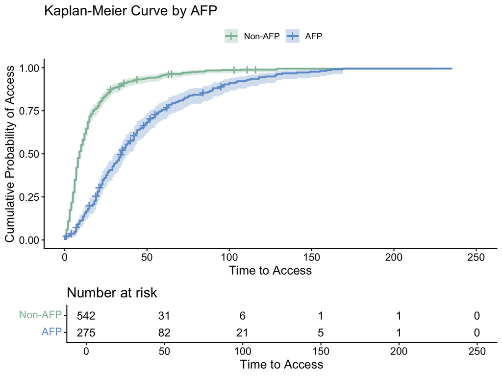

###### 3.3.2.2.0.2 Model

|  | **HR** | **95% CI** | **p-value** |
| --- | --- | --- | --- |
| afp |  |  |  |
| Non-AFP | — | — |  |
| AFP | 0.30 | 0.25 - 0.35 | <0.001 |
| referral |  |  |  |
| Continuing therapy | — | — |  |
| New medication | 0.88 | 0.75 - 1.03 | 0.121 |
| frailty(site) |  |  | <0.001 |

Abbreviations: CI = Confidence Interval, HR = Hazard Ratio

### 3.3.3 Pharmacist Time

#### 3.3.3.1 Outcome

| **Characteristic** | **N** | **afp** **Non-AFP** N = 547 | **afp** **AFP** N = 299 |
| --- | --- | --- | --- |
| PharmD time spent on access | 846 |  |  |
| Mean (SD) |  | 1.2 (1.1) | 3.4 (3.5) |
| Median (Q1 - Q3) |  | 1.0 (0.5 - 2.0) | 2.0 (1.0 - 4.0) |
| Min - Max |  | 0.0 - 10.0 | 0.5 - 30.0 |

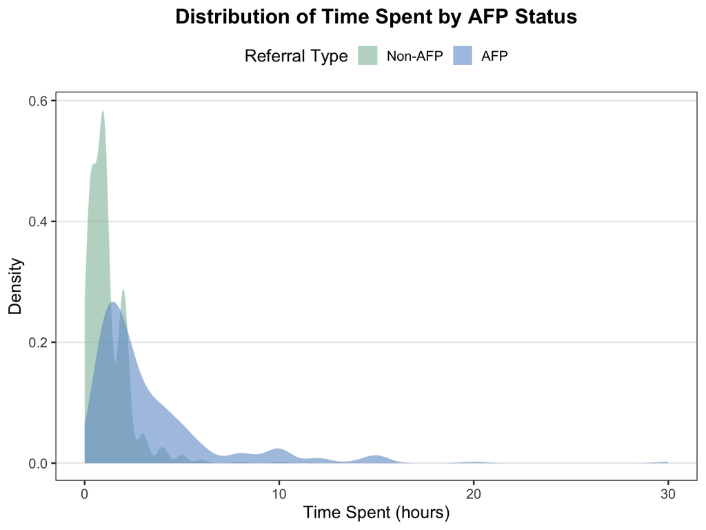

#### 3.3.3.2 Cumulative Link Mixed Effects Model

Cumulative Link Mixed Model Results

| Term | Log(OR) | Odds Ratio | 95% CI for OR Lower | 95% CI for OR Upper | P-value |
| --- | --- | --- | --- | --- | --- |
| afpAFP | 2.826 | 16.872 | 12.292 | 23.158 | <0.001 |
| referralNew medication | 0.790 | 2.204 | 1.684 | 2.884 | <0.001 |

### 3.3.4 Treatment gap

#### 3.3.4.1 Outcome

| **Characteristic** | **N** | **afp** **Non-AFP** N = 547<sup>1</sup> | **afp** **AFP** N = 299<sup>1</sup> |
| --- | --- | --- | --- |
| Treatment Gap | 489 |  |  |
| Yes |  | 6 (1.89%) | 49 (28.7%) |
| No |  | 301 (94.7%) | 104 (60.8%) |
| Unknown |  | 11 (3.46%) | 18 (10.5%) |
| Missing |  | 229 | 128 |

<sup>1</sup> n (%)

| **Characteristic** | **N** | **Referral Status** **Continuing therapy** N = 483<sup>1</sup> | **Referral Status** **New medication** N = 363<sup>1</sup> |
| --- | --- | --- | --- |
| Treatment Gap | 489 |  |  |
| Yes |  | 55 (11.4%) | 0 (0%) |
| No |  | 399 (82.6%) | 6 (100.0%) |
| Unknown |  | 29 (6.00%) | 0 (0%) |
| Missing |  | 0 | 357 |
| AFP | 846 |  |  |
| Non-AFP |  | 312 (64.6%) | 235 (64.7%) |
| AFP |  | 171 (35.4%) | 128 (35.3%) |

<sup>1</sup> n (%)

#### 3.3.4.2 Mixed effects logistic regression models

**Note**

- Only including patients continuing therapy
- Low event rate, but model appears fairly stable despite large coefs
- Some patients were marked as “Unknown” - Treated them similiarly as the Unknowns for the primary outcome where a model is created for three cases.

**Drop unknown**

Mixed-Effects Logistic Regression Results: Treatment gap outcome (Drop unknowns)

| Term | Log(OR) | Odds Ratio | 95% CI for OR Lower | 95% CI for OR Upper | P-value |
| --- | --- | --- | --- | --- | --- |
| (Intercept) | -3.694 | 0.025 | 0.010 | 0.064 | <0.001 |
| afpAFP | 3.353 | 28.582 | 11.377 | 71.807 | <0.001 |

**Unknown as Yes**

| Term | Log(OR) | Odds Ratio | 95% CI for OR Lower | 95% CI for OR Upper | P-value |
| --- | --- | --- | --- | --- | --- |
| (Intercept) | -2.740 | 0.065 | 0.035 | 0.119 | <0.001 |
| afpAFP | 2.531 | 12.567 | 6.902 | 22.879 | <0.001 |

**Unknown as No**

| Term | Log(OR) | Odds Ratio | 95% CI for OR Lower | 95% CI for OR Upper | P-value |
| --- | --- | --- | --- | --- | --- |
| (Intercept) | -3.721 | 0.024 | 0.01 | 0.061 | <0.001 |
| afpAFP | 3.187 | 24.205 | 9.85 | 59.480 | <0.001 |

### 3.3.5 PAP approval

| AFP | Approval Status | N | Percent |
| --- | --- | --- | --- |
| Non-AFP | Approved | 41 | 0.0749543 |
| Non-AFP | Denied | 6 | 0.0109689 |
| Non-AFP | Did not apply | 499 | 0.9122486 |
| Non-AFP | NA | 1 | 0.0018282 |
| AFP | Approved | 88 | 0.2943144 |
| AFP | Denied | 107 | 0.3578595 |
| AFP | Did not apply | 104 | 0.3478261 |

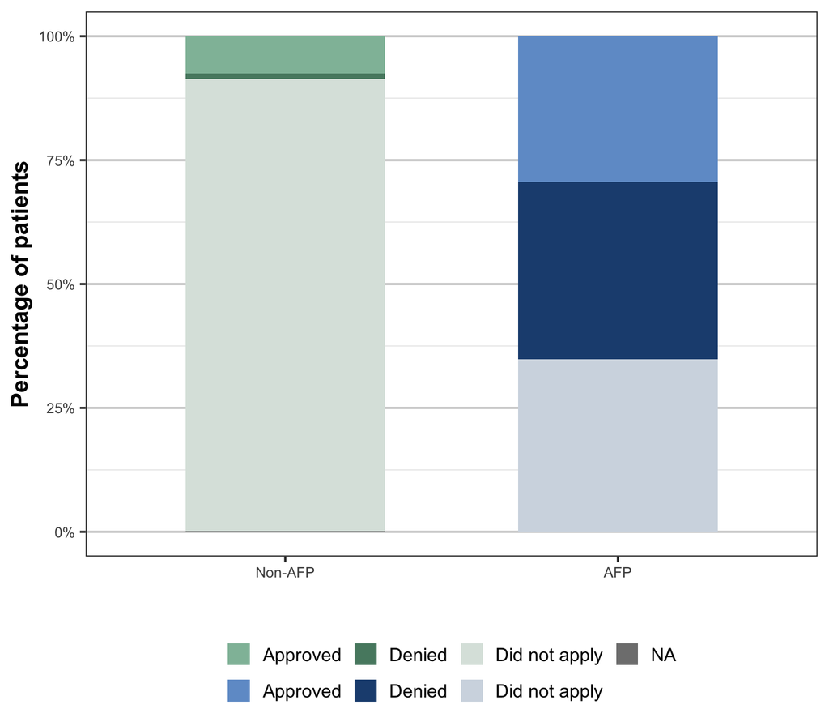